# RUSH RNA-seq Analysis

## 1. Data import :

4 sample groups: AD+male, AD+female, Control+male, Control+female sample infos like accession numbers are given in the overview tables

```r
library(tximport)
library(dplyr)
library(ggplot2)
library(DESeq2)
```

```r
## importing files , locally stored
dir.ADM<- "~/rush_data/ADmale"
dir.ADF<- "~/rush_data/ADfemale"
dir.CF <- "~/rush_data/ControlFemale"
dir.CM <- "~/rush_data/ControlMale"

overview.ADM <- read.csv("~/DataScienceProject/RushData/overviews/ADmale_overview.csv", header=TRUE)
overview.ADF <- read.csv("~/DataScienceProject/RushData/overviews/ADfemale_overview.csv", header=TRUE)
overview.CF <- read.csv("~/DataScienceProject/RushData/overviews/ControlFemale_overview.csv", header=TRUE)
overview.CM <- read.csv("~/DataScienceProject/RushData/overviews/ControlMale_overview.csv", header=TRUE)


files.ADM <- file.path(dir.ADM, paste0(overview.ADM$file_name, ".tsv"))
names(files.ADM) <-overview.ADM$Accession
files.ADF <- file.path(dir.ADF, paste0(overview.ADF$file_name, ".tsv"))
names(files.ADF) <-overview.ADF$Accession
files.CF <- file.path(dir.CF, paste0(overview.CF$file_name, ".tsv"))
names(files.CF) <-overview.CF$Accession
files.CM <- file.path(dir.CM, paste0(overview.CM$file_name, ".tsv"))
names(files.CM) <-overview.CM$Accession
```

modifying age to a binary variable: TRUE under 90, FALSE: over or equal to 90

```r
change.age.column <- function(overview){
  overview$age <- as.numeric(gsub("[A-z]","", overview$Biosample.age))

  overview <- mutate(overview, age.binary = age < 90 )


  return(overview)
  }

overview.CF <- change.age.column(overview.CF)
overview.CM <- change.age.column(overview.CM)
overview.ADF <- change.age.column(overview.ADF)
overview.ADM <- change.age.column(overview.ADM)


# number of samples
number.controlsamples <- length(files.CF)+ length(files.CM)
number.ADsamples<-  length(files.ADF)+ length(files.ADM)
```

reading in the count data which is given in rsem format

```r
# combining all rna seq data to one rsem object
files.all <- c(files.CF, files.CM, files.ADF, files.ADM)
txi.rsem <- tximport(files.all, type = "rsem", txIn = FALSE, txOut = FALSE)
```

```
reading in files with read_tsv
1 2 3 4 5 6 7 8 9 10 11 12 13 14 15 16 17 18 19 20 21 22 23 24 25 26 27 28 29 30 31 32 33 34 35 36 37 38 39 40 41 42 43 44 45 46 47 48 49 50 51 52 53 54 55 56 57 58 59 60 61 62 63 64 65 66 67 68 69 70 71 72 73 74 75 76 77 78 79 80 81
```

## 2. Data preparation for DESeq2

pre-filtering genes with length 0 and count 0

```r
zero_length_and_unexpressed = (apply(txi.rsem$abundance, 1, max) == 0) &
  (apply(txi.rsem$length, 1, min) == 0)

txi.rsem$length = txi.rsem$length[!zero_length_and_unexpressed,]
txi.rsem$abundance = txi.rsem$abundance[!zero_length_and_unexpressed,]
txi.rsem$counts = txi.rsem$counts[!zero_length_and_unexpressed,]
```

create sample table with info about condition, age and sex

```r
condition<- factor(c(rep("C", length(files.CF) + length(files.CM) ),
                    rep("AD",length(files.ADF)+  length(files.ADM))
                    ))

sex<- factor(c(rep("F", length(files.CF)),
               rep("M", length(files.CM)),
               rep("F",length(files.ADF)),
               rep("M", length(files.ADM))
              ))

age.binary<- (c( overview.CF$age.binary,  overview.CM$age.binary, overview.ADF$age.binary, overview.ADM$age.binary ))
age<- (c( overview.CF$age,  overview.CM$age, overview.ADF$age, overview.ADM$age ))


sampletable <- data.frame(condition= condition, sex=sex, age.binary=age.binary, age=age)
sampletable
```

| condition | sex | age.binary | age |
| --- | --- | --- | --- |
| C | F | TRUE | 85 |
| C | F | TRUE | 75 |
| C | F | FALSE | 90 |
| C | F | TRUE | 87 |
| C | F | TRUE | 83 |
| C | F | FALSE | 90 |
| C | F | FALSE | 90 |
| C | F | TRUE | 77 |
| C | F | TRUE | 83 |
| C | F | TRUE | 84 |

[output cut: 71 more lines]

[output not shown]

now dds.all object can be created with design including binary variable age, sex and condition for an exclusively female/male study , object dds is created

```r
dds.all <- DESeqDataSetFromTximport(txi = txi.rsem ,colData = sampletable ,design = ~ age.binary+ sex + condition)
```

```
using counts and average transcript lengths from tximport
```

```r
dds <- DESeqDataSetFromTximport(txi = txi.rsem ,colData = sampletable ,design = ~ age.binary + condition)
```

```
using counts and average transcript lengths from tximport
```

filtering out ERCC counts (no genes) and genes with low expression across all samples

```r
#ERCC counts:
dds<- dds[1:(nrow(dds)-90),]
dds.all<- dds.all[1:(nrow(dds.all)-90),]

# low gene expression measurements across all samples
dds <- dds[ rowSums(counts(dds)) > 1, ]
dds.all <- dds.all[ rowSums(counts(dds.all)) > 1, ]

# creating object to test also exclusively  male/female samples
dds.female <- dds[, which(sex=="F")]
dds.male<- dds[, which(sex=="M")]
```

## 3. Data Exploration

Age distribution - unbalanced, a lot of 90+ patients in AD groups

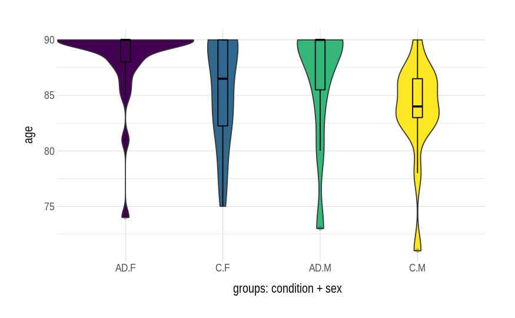

```r
library(viridis)
#library(forcats)
#library(hrbrthemes)
# unbalanced, a lot of 90+ patients in AD groups

ggplot( sampletable, aes(x=interaction(condition, sex), y=age, fill=interaction( condition, sex))) +
  geom_violin(width=1.4) +
  geom_boxplot(width=0.1, color="black", alpha=0.2) +
  scale_fill_viridis(discrete = TRUE) +
  theme_ipsum() +
  theme(
    legend.position="none",
    plot.title = element_text(size=16),
    axis.title.y = element_text(hjust=0.55, vjust= 3 ,size= 13 ),
    axis.title.x = element_text(hjust=0.55 , vjust= -1.4 ,size= 13 )
    )+
  xlab("groups: condition + sex")
```

Fold change comparison - 1:1 comparsion between two samples -transformed counts for meaningful plots:  
- log2 transformated normalized counts - vst transformed counts, vst: variance stabilizing transformation of the counts

```r
dds.all <- estimateSizeFactors(dds.all)
```

```
using 'avgTxLength' from assays(dds), correcting for library size
```

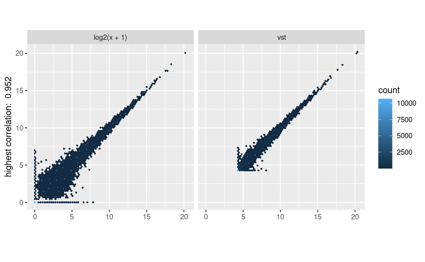

```r
vsd <- vst(dds.all, blind=F)

create_log2_comparsion <- function(rows){

  counts <- counts(dds.all, normalized=T)
  colnames<- colnames(counts)[rows]
  df <- bind_rows(
    as_data_frame(log2(counts[, rows]+1)) %>%
      mutate(transformation = "log2(x + 1)"),
    as_tibble(assay(vsd)[, rows]) %>% mutate(transformation = "vst"),
  #  as_data_frame(assay(rld)[, 1:2]) %>% mutate(transformation = "rlog")
  )

  colnames(df)[1:2] <- c("x", "y")

  plot<- ggplot(df, aes(x = x, y = y))+ geom_hex(bins = 80) +
  coord_fixed() + facet_grid( . ~ transformation)  +
    xlab("") +
    ylab("")

  return(plot)
}

# plotting two random samples within the same group
plot_cf<- create_log2_comparsion(c(1,2)) # 2 control, female samples
plot_cm<- create_log2_comparsion(c(27,28)) # 2 control, male samples
plot_af <- create_log2_comparsion(c(42,43)) # 2 AD, female samples
plot_am <- create_log2_comparsion(c(71,72)) # 2 AD, male samples


#plotting samples with highest and lowest correlation

# calculating pairwise corrleation
cor.mat<- counts(dds.all , normalized=T) %>% cor( method="spearman")
# finding max and min correlated samples
min.cor <- which(cor.mat ==min(cor.mat), arr.ind = T)
min.val <- min(cor.mat)
cor.mat[which(cor.mat ==max(cor.mat), arr.ind = T)]=0
max.cor <-which(cor.mat ==max(cor.mat), arr.ind = T)
max.val<- max(cor.mat)

# highest correlation between two samples of group: control + male
# lowest correlation between sample of AD male and Control Female

# plotting those samples
create_log2_comparsion(max.cor[1,]) + ylab(paste("highest correlation: ", round(max.val, digit=3)))
```

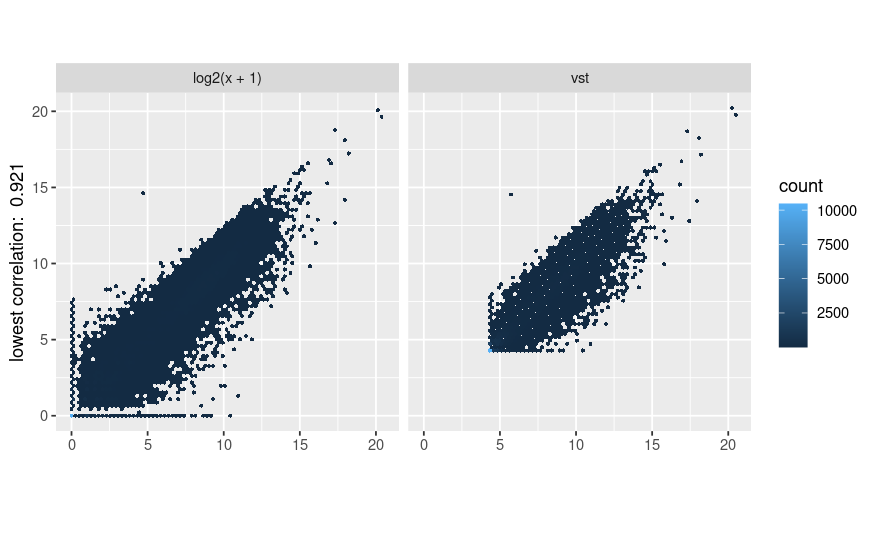

```r
create_log2_comparsion(min.cor[1,]) + ylab(paste("lowest correlation: ", round(min.val, digit=3)))
```

```r
library("pheatmap")
library("RColorBrewer")
sampleDists <- dist(t(assay(vsd)))
sampleDistMatrix <- as.matrix(sampleDists)
rownames(sampleDistMatrix) <- paste(vsd$condition, vsd$sex, vsd$age, sep="-")
colnames(sampleDistMatrix) <- NULL
colors <- colorRampPalette( rev(brewer.pal(9, "Blues")) )(255)
pdf("~/DataScienceProject/heatmap.png", height=10)
pheatmap(sampleDistMatrix,
         clustering_distance_rows=sampleDists,
         clustering_distance_cols=sampleDists,
         col=colors)
dev.off()
```

Principal Component Analysis - clustering according their sex and not condition ! - very low variance of the two first PCs covered

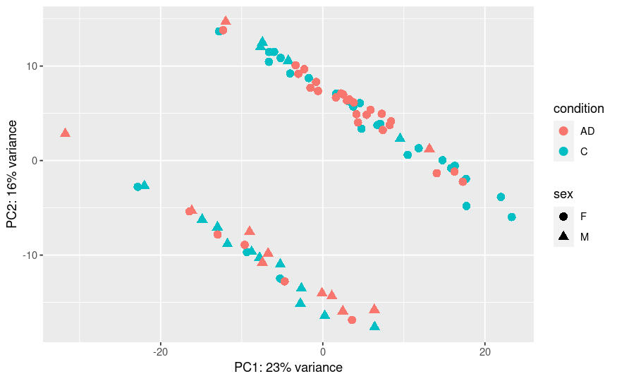

```r
pcaData <- plotPCA(vsd, intgroup= c("condition", "age.binary", "sex"), returnData=TRUE)
percentVar <- round(100 * attr(pcaData, "percentVar"))

ggplot(pcaData, aes(PC1, PC2, shape=sex, color=condition)) +
  geom_point(size=3) +
  xlab(paste0("PC1: ",percentVar[1],"% variance")) +
  ylab(paste0("PC2: ",percentVar[2],"% variance"))
```

## 3. Differential Expression Analysis via DESeq2

as expected from results of data exploration, samples seems to similar to detect any dif. expressed genes only 7 diff. expr. gene detected !

```r
analyzed.dds.all <- DESeq(dds.all)
```

```
-- replacing outliers and refitting for 100 genes
-- DESeq argument 'minReplicatesForReplace' = 7
-- original counts are preserved in counts(dds)
```

```r
#analyzed.dds.male <- DESeq(dds.male)
#analyzed.dds.female <- DESeq(dds.female)

res <- results(analyzed.dds.all ,alpha=0.05)
#res.dds.male <- results(analyzed.dds.male ,alpha=0.05)
#res.dds.female <- results(analyzed.dds.female ,alpha=0.05)

summary(res)
```

```
out of 41406 with nonzero total read count
adjusted p-value < 0.05
LFC > 0 (up)       : 3, 0.0072%
LFC < 0 (down)     : 4, 0.0097%
outliers [1]       : 12, 0.029%
low counts [2]     : 5, 0.012%
(mean count < 0)
[1] see 'cooksCutoff' argument of ?results
[2] see 'independentFiltering' argument of ?results
```

```r
pvalues <- p.adjust(res$pvalue, method = "BH")
sum(pvalues<0.05,na.rm = T)
```

```
[1] 7
```

```r
# only 7  diff. expr. gene detected !!!
```

overview of the gene expression status: not significant, overexpressed or underexpressed in AD patients

```r
data<- tibble(log2FoldChange=res$log2FoldChange, padj= res$padj,genes=gsub("\\..*", "", rownames(res)))
data<- data %>%
  mutate(gene_type = case_when(log2FoldChange > 0 & pvalues < 0.05 ~ "upregulated",
                               log2FoldChange < 0 & pvalues < 0.05 ~ "downregulated",
                               TRUE ~ "not significant"))
print(table(data$gene_type))
```

```
  downregulated not significant     upregulated
              4           41404               3
```

saving differential expressed genes and converting ensembl id to gene symbol via biomaRt unfortunately, conversion is not 1:1, some ensembl genes do not have a hgnc symbol

```r
library(biomaRt)

dif.genes<- data[which(data$gene_type !="not significant"), ]
mart <- useMart(dataset="hsapiens_gene_ensembl","ensembl")
```

```
Ensembl site unresponsive, trying useast mirror
Ensembl site unresponsive, trying useast mirror
```

```r
G_list <- getBM(filters= "ensembl_gene_id",
                attributes=c( 'ensembl_gene_id',
                              'hgnc_symbol', 'gene_biotype'),
                values= dif.genes$genes,
                mart= mart)

dif.genes<- left_join(dif.genes, G_list, by= c( "genes" = "ensembl_gene_id" ))
dif.genes
```

| log2FoldChange | padj | genes | gene_type | hgnc_symbol | gene_biotype |
| --- | --- | --- | --- | --- | --- |
| -1.2371521 | 4.374166e-02 | ENSG00000109061 | downregulated | MYH1 | protein_coding |
| 0.1584699 | 1.992992e-02 | ENSG00000173163 | upregulated | COMMD1 | protein_coding |
| -20.6981101 | 9.627836e-07 | ENSG00000235558 | downregulated | GUSBP17 | unprocessed_pseudogene |
| -17.9340485 | 9.931835e-05 | ENSG00000254673 | downregulated |  | protein_coding |
| -18.9432886 | 2.037583e-05 | ENSG00000274791 | downregulated | NA | NA |
| 1.6845487 | 1.992992e-02 | ENSG00000275496 | upregulated |  | lncRNA |
| 6.8608674 | 1.992992e-02 | ENSG00000278774 | upregulated |  | snRNA |

[output not shown]

# supplementary

trying out different adjustment, batch correction for sex PCA for both methods are still not showing distance between AD and control samples

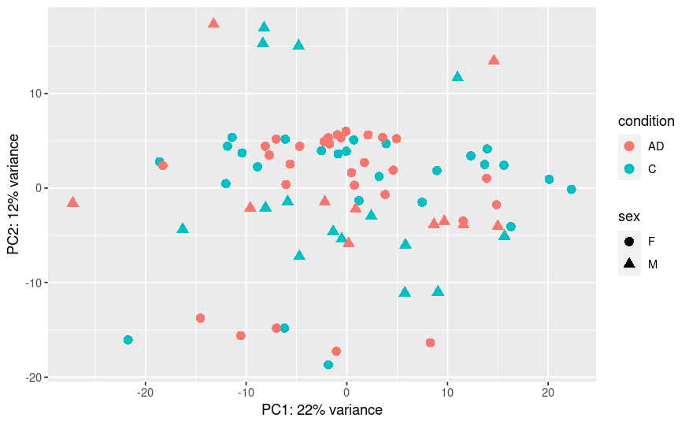

```r
assay(vsd) <- limma::removeBatchEffect(assay(vsd), vsd$sex)

pcaData <- plotPCA(vsd, intgroup= c("condition", "sex"), returnData=TRUE)
percentVar <- round(100 * attr(pcaData, "percentVar"))
ggplot(pcaData, aes(PC1, PC2, color=condition, shape=sex)) +
  geom_point(size=3) +
  xlab(paste0("PC1: ",percentVar[1],"% variance")) +
  ylab(paste0("PC2: ",percentVar[2],"% variance"))
```

```r
library(sva)
# using combatseq to correct for sex
combatseq_counts<- ComBat_seq(as.matrix(assay(dds.all)), batch = sex, group=condition )
```

```
Found 2 batches
Using full model in ComBat-seq.
Adjusting for 1 covariate(s) or covariate level(s)
Estimating dispersions
Fitting the GLM model
Shrinkage off - using GLM estimates for parameters
Adjusting the data
```

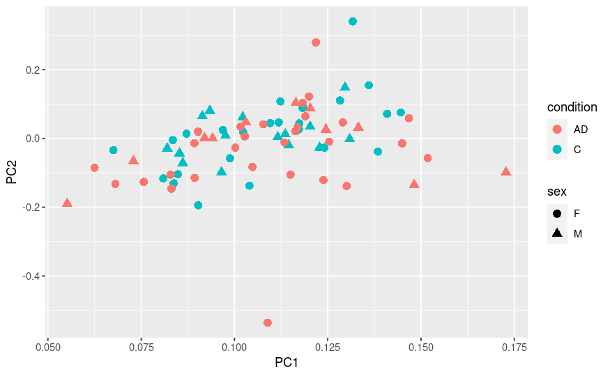

```r
# PCA
pca_combatseq<- as.data.frame(prcomp(combatseq_counts)[2]$rotation)
pca_combatseq$condition<- condition
ggplot(pca_combatseq, aes(PC1, PC2, color=condition, shape = sex)) +
  geom_point(size=3)
```

```r
# still not showing distance between AD and control samples
```